PUBPOL 543

Deliverable 2: “Bivariate Plot”

Note: The dataset used for this assignment was sourced from the US Government’s open data repository: https://catalog.data.gov/ (last accessed, February 5, 2023)

The dataset contains information on data breach incidents reported by legal entities from different industries. In this, the Washington state laws requires legal entities to notify authorities whenever they have been exposed to data breaches compromising information on more than 500 Washingtonians.

I will start this exercise by creating a bivariate plot that illustrates the relationship between two categorical variables.

In particular, I will explore whether specific industries (e.g. healthcare, business, finance, etc.) are associated with a higher exposure to a particular cause of data breach incidents (e.g. cyber-attack, theft, unauthorized access).

```r
#Cleaning the memory:
rm(list = ls())

#Providing the link to the data in the Github repository:
location='https://github.com/elenapopic543/Bivariate_Deliverable2/raw/main/'
file='Data_Breach_Notifications_Affecting_Washington_Residents.csv'
link=paste0(location,file)

#Reading-in the data from the Github repository location:
data1 <- read.csv(file=url(link), header=TRUE, stringsAsFactors=FALSE)

#Excluding the missing values:
data1=na.omit(data1)

#Examining the data types:
#str(data1,width = 70,strict.width='cut')
```

```r
#Examining unique values:
unique(data1$DataBreachCause)
```

```
## [1] "Cyberattack"         "Unauthorized Access" "Theft or Mistake"
```

```r
#Examining unique values:
unique(data1$IndustryType)
```

```
## [1] "Health"             "Business"           "Finance"
## [4] "Non-Profit/Charity" "Education"          "Government"
```

```r
library(dplyr)
#Simplifying one of the values in the IndustryType variable:
data1 = data1 %>%
mutate(IndustryType = if_else(IndustryType == "Non-Profit/Charity", "Non-Profit", IndustryType))

#Creating a contingency table:
BreachCause = table(data1$DataBreachCause[data1$IndustryType != "Government"], data1$IndustryType[data1$IndustryType != "Government"]) #no incidents other than unauthorized access

#Generating columns with proportions based on the previously created counts table:
library(magrittr)
(Breach_Col=prop.table(BreachCause,
                            margin = 2)
                             %>%round(.,3))
```

```
##
##                       Business Education Finance Health Non-Profit
##   Cyberattack            0.758     0.867   0.645  0.659      0.984
##   Theft or Mistake       0.015     0.089   0.032  0.171      0.000
##   Unauthorized Access    0.227     0.044   0.323  0.171      0.016
```

The above table explores whether specific industries (e.g. healthcare, business, finance, etc.) are associated with a higher incidence of particular data breach causes (e.g. cyber-attack, theft, unauthorized access).

```r
#Creating a dataframe based on the contingency tables:
(BreachDF=as.data.frame(BreachCause))
```

```
##                   Var1       Var2 Freq
## 1          Cyberattack   Business  100
## 2     Theft or Mistake   Business    2
## 3  Unauthorized Access   Business   30
## 4          Cyberattack  Education   39
## 5     Theft or Mistake  Education    4
## 6  Unauthorized Access  Education    2
## 7          Cyberattack    Finance   20
## 8     Theft or Mistake    Finance    1
## 9  Unauthorized Access    Finance   10
## 10         Cyberattack     Health   27
## 11    Theft or Mistake     Health    7
## 12 Unauthorized Access     Health    7
## 13         Cyberattack Non-Profit   62
## 14    Theft or Mistake Non-Profit    0
## 15 Unauthorized Access Non-Profit    1
```

```r
as.data.frame(Breach_Col)
```

```
##                   Var1       Var2  Freq
## 1          Cyberattack   Business 0.758
## 2     Theft or Mistake   Business 0.015
## 3  Unauthorized Access   Business 0.227
## 4          Cyberattack  Education 0.867
## 5     Theft or Mistake  Education 0.089
## 6  Unauthorized Access  Education 0.044
## 7          Cyberattack    Finance 0.645
## 8     Theft or Mistake    Finance 0.032
## 9  Unauthorized Access    Finance 0.323
## 10         Cyberattack     Health 0.659
## 11    Theft or Mistake     Health 0.171
## 12 Unauthorized Access     Health 0.171
## 13         Cyberattack Non-Profit 0.984
## 14    Theft or Mistake Non-Profit 0.000
## 15 Unauthorized Access Non-Profit 0.016
```

```r
BreachDF$share=as.data.frame(Breach_Col)[,3]
#Changing column names:
names(BreachDF)[1:4]=c("Cause", "Industry", "Counts","Share")
#BreachDF
```

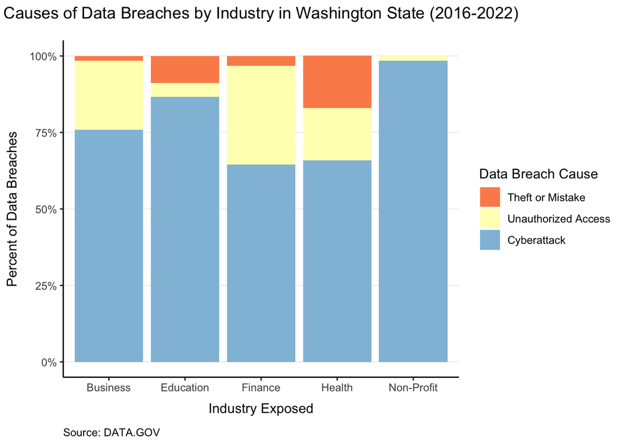

```r
#Loading necessary packages:
library(ggplot2)
library(RColorBrewer)

#Creating the base for our plot:
base1=ggplot(data=BreachDF,
             aes(x=Industry,
                 y=Share,
                 fill=reorder(Cause,Share))) #ordered

#Defining the color-scheme:
colors <- brewer.pal(3, "RdYlBu")

#Creating a stack style plot:
barStacked = base1 + theme_classic() + theme(panel.grid.major.y = element_line(colour = gray(0.95))) +
            geom_bar(stat = "identity", position = 'stack') +
            labs(x = "Industry Exposed", y = "Percent of Data Breaches", fill = "Data Breach Cause") +  scale_fill_manual(values = colors) + ggtitle("Causes of Data Breaches by Industry in Washington State (2016-2022)") + theme(plot.title = element_text(hjust = 0.5))

# Adding caption and defining labels:
caption ="Source: DATA.GOV"
#barStacked2 = barStacked + labs(caption = caption) +
          #theme(plot.caption = element_text(hjust = 0, margin = margin(t = 10, r = 0, b = 0, l = 0))) +
              #geom_text(size = 2.5, position = position_stack(vjust = 0.5),
              #aes(label=percent(Share,accuracy = 0.1)))+ scale_y_continuous(labels = percent) +
              #theme(plot.caption = element_text(hjust = 0, margin = margin(t = 5)),
              #plot.title = element_text(hjust = 0.5, margin = margin(b = 10), size = 12),
              #axis.title.x = element_text(margin = margin(t = 8)),
              #axis.title.y = element_text(margin = margin(r = 8)))
#barStacked2

#Removing percent labels to make the plot less visually crowded (the proportions are clearly conveyed by colors in this case):

barStacked3 = barStacked + labs(caption = caption) + scale_y_continuous(labels=scales::percent_format())         + theme(plot.caption = element_text(hjust = 0, margin = margin(t = 10, r = 0, b = 0, l = 0)),
        plot.title = element_text(hjust = 0.5, margin = margin(b = 15)),
        axis.title.x = element_text(margin = margin(t = 8)),
        axis.title.y = element_text(margin = margin(r = 8)))

barStacked3
```

Interpretation: The above plot explores how different types of industries are associated with a higher incidence of a particular cause of data breaches (cyber-attacks, thefts/mistakes, or unauthorized access). While cyber attacks are the predominant cause of data breaches in all industries, there are industry-specific patterns as well. For instance, the non-profit sector tends to be more prone to cyber-attacks with only an insignificant share of other incidents. In contrast, the finance industry appears to be more exposed than others to instances of unauthorized access to data, while the health sector exhibits the largest share of data breaches caused by theft or mistakes.

Note: While a previous version of the plot included percent labels inside bars, these were removed to make the graph less visually crowded, as the proportions are clearly conveyed by colors in this specific case.

Appendix:

Additional variables and plots that I have explored for this dataset:

In the following, I will explore the number of Washingtonians affected in data breaches by the type of industry where the data breach incidents occurred (i.e., perform a Categorical-Numerical bivariate relationship analysis).

```r
#Providing the link to the data in the Github repository:
location='https://github.com/elenapopic543/Bivariate_Deliverable2/raw/main/'
file='Data_Breach_Notifications_Affecting_Washington_Residents.csv'
link=paste0(location,file)

#Reading-in the data from the Github repository location:
data1 <- read.csv(file=url(link), header=TRUE, stringsAsFactors=FALSE)
```

```r
#Examining data types:
#str(data1,width = 70,strict.width='cut')
```

```r
#Summarizing the variable reflecting the number of people affected by the data breach:
#summary(data1$WashingtoniansAffected)
```

```r
#Excluding the missing values:
data1=na.omit(data1)
```

```r
#Getting the median of exposed residents for each industry type:
#aggregate(data=data1, WashingtoniansAffected~IndustryType,median)
```

```r
library(dplyr)
#Simplifying one of the values in the IndustryType variable:
data1 = data1 %>%
mutate(IndustryType = if_else(IndustryType == "Non-Profit/Charity", "Non-Profit", IndustryType))
#unique(data1$IndustryType)
```

```r
#Getting the mean of exposed residents for each industry type:
aggregate(data=data1, WashingtoniansAffected~IndustryType,mean)
```

```
##   IndustryType WashingtoniansAffected
## 1     Business              6284.9318
## 2    Education              8226.6667
## 3      Finance              4929.4839
## 4   Government               939.3333
## 5       Health             26375.7317
## 6   Non-Profit             42347.8254
```

```r
#Checking other statistics:
#tapply(data1$WashingtoniansAffected,
       #data1$IndustryType, summary)
```

```r
library(ggplot2)
library(ggpubr)

base1=ggplot(data=data1[data1$WashingtoniansAffected>=1500,],
            aes(x=IndustryType,y=WashingtoniansAffected))
box1=base1 + geom_boxplot() + labs(title = "1.5k residents and above")

base2=ggplot(data=data1[data1$WashingtoniansAffected>=20000,],
            aes(x=IndustryType,y=WashingtoniansAffected))
box2=base2 + geom_boxplot() + labs(title = "20k residents and above")

base3=ggplot(data=data1[data1$WashingtoniansAffected>=100000,],
            aes(x=IndustryType,y=WashingtoniansAffected))
box3=base3 + geom_boxplot() + labs(title = "100k residents and above")

#ggarrange(box1,box2,box3,ncol = 1)
```

```r
#Moving forward, I will focus my analysis on data breach incidents with a significant number of exposed individuals.

titleText2="Data Breaches Affecting over 50,000 People by Industry of Occurrence (WA, 2016-2022)"
sourceText='Source: DATA.GOV'
base4=ggplot(data=data1[data1$WashingtoniansAffected>=50000,],
            aes(x=IndustryType,y=WashingtoniansAffected))
box4=base4 + geom_boxplot() + labs(title = titleText2)

#box4 + coord_flip()
```

```r
#Reordering by the median value of incidents:
base5=ggplot(data=data1[data1$WashingtoniansAffected>=50000,],
            aes(x=reorder(IndustryType,
                          WashingtoniansAffected,
                          median,
                y=WashingtoniansAffected)))
box4=base4 + geom_boxplot() + labs(title = titleText2)

#box5  + coord_flip()
```

```r
#Creating a histogram with facets:
baseHY=ggplot(data=data1[data1$WashingtoniansAffected >= 10000,], aes(x=WashingtoniansAffected))
histHY=baseHY + geom_histogram(aes(fill=IndustryType),
                              color='black') + labs(title = titleText2, caption = sourceText,
                              x = "Number of People Affected", y = "Number of Data Breaches",) +
scale_x_continuous(limits = c(0,500000),
labels = c("50000", "100000","200000","300000","400000","500000"))
#histHY + facet_grid(~IndustryType)
```

[figure not shown]

```r
#Further customizing the theme of the histogram:
library(RColorBrewer)
my_colors = brewer.pal(5, "Blues")
histHY2 = histHY + theme(plot.caption = element_text(hjust = 0, margin = margin(t = 5), size=8),
                   plot.title = element_text(hjust = 0.5, margin = margin(b = 10), size = 12),
                   axis.title.x = element_text(margin = margin(t = 8), size=10),
                   axis.title.y = element_text(margin = margin(r = 8), size=10))
histHY2 + facet_grid(IndustryType~.) + guides(fill="none") + scale_fill_manual(values = my_colors)
```